# Entrega2_Proyecto1

Gustavo Cruz; Pedro Guzman

2025-02-12

Repositorio: https://github.com/G2309/MD_Proyecto2.git

```r
movies <- read.csv('movies.csv', stringsAsFactors = FALSE)
```

## Determinación de la cantidad de grupos

```r
library(tidyverse)
library(cluster)
library(factoextra)
```

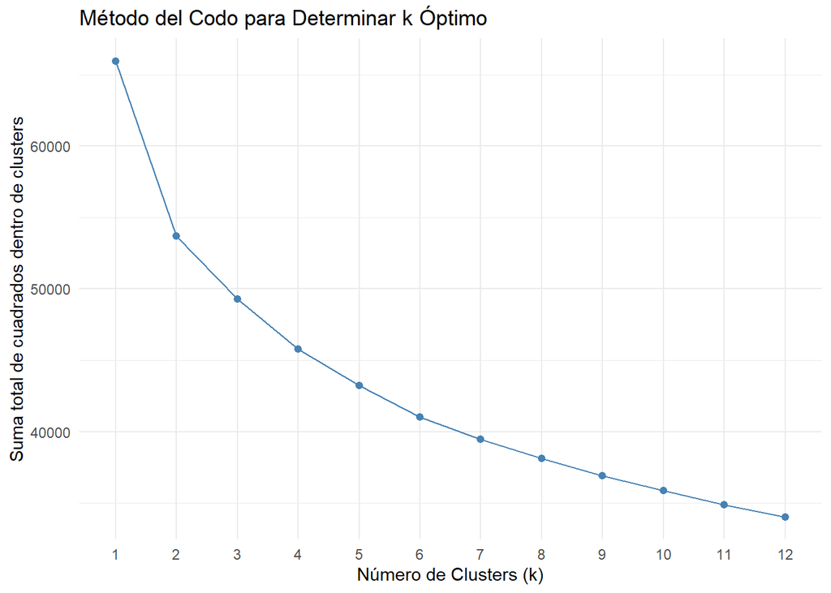

```r
# Función para remover outliers usando IQR
remove_outliers <- function(x) {
  qnt <- quantile(x, probs=c(.25, .75), na.rm=TRUE)
  H <- 1.5 * IQR(x, na.rm=TRUE)
  x[x < (qnt[1] - H)] <- NA
  x[x > (qnt[2] + H)] <- NA
  return(x)
}

movies_clean <- movies %>%
  select(popularity, budget, revenue, runtime,
         genresAmount, productionCoAmount,
         productionCountriesAmount, voteCount,
         voteAvg, actorsAmount,
         castWomenAmount, castMenAmount) %>%
  mutate(across(everything(), as.numeric)) %>%
  # Remover outliers
  mutate(across(everything(), remove_outliers)) %>%
  # Eliminar filas con NA
  na.omit()

movies_scaled <- scale(movies_clean)

set.seed(531) # Seed para reproducibilidad
wss <- numeric(12)
for (k in 1:12) {
  km <- kmeans(movies_scaled,
               centers = k,
               nstart = 50,
               iter.max = 50)
  wss[k] <- km$tot.withinss
}

p <- fviz_nbclust(movies_scaled,
             kmeans,
             method = "wss",
             k.max = 12,
             nstart = 50,
             iter.max = 50) +
  labs(title = "Método del Codo para Determinar k Óptimo",
       x = "Número de Clusters (k)",
       y = "Suma total de cuadrados dentro de clusters") +
  theme_minimal()

print(p)
```

```r
wss_diff <- diff(wss) / wss[-length(wss)] * 100
print("\nReducción porcentual en WSS para cada k adicional:")
```

```
## [1] "\nReducción porcentual en WSS para cada k adicional:"
```

```r
for(i in 1:length(wss_diff)) {
  cat(sprintf("De %d a %d clusters: %.2f%% de reducción\n",
              i, i+1, abs(wss_diff[i])))
}
```

```
## De 1 a 2 clusters: 18.56% de reducción
## De 2 a 3 clusters: 8.22% de reducción
## De 3 a 4 clusters: 7.14% de reducción
## De 4 a 5 clusters: 5.53% de reducción
## De 5 a 6 clusters: 5.09% de reducción
## De 6 a 7 clusters: 3.86% de reducción
## De 7 a 8 clusters: 3.40% de reducción
## De 8 a 9 clusters: 3.12% de reducción
## De 9 a 10 clusters: 2.84% de reducción
## De 10 a 11 clusters: 2.76% de reducción
## De 11 a 12 clusters: 2.46% de reducción
```

## Agrupamiento

```r
# Para el ejercicio 2 de clustering estare utilizando la seed 531
movies_clean <- movies %>%
  select(popularity, budget, revenue, runtime,
         genresAmount, productionCoAmount,
         productionCountriesAmount, voteCount,
         voteAvg, actorsAmount,
         castWomenAmount, castMenAmount) %>%
  mutate(across(everything(), as.numeric)) %>%
  mutate(across(everything(), remove_outliers)) %>%
  na.omit()

movies_scaled <- scale(movies_clean)

set.seed(531)
kmeans_result <- kmeans(movies_scaled,
                       centers = 4,
                       nstart = 50,
                       iter.max = 50)

set.seed(531)
sample_size <- min(1000, nrow(movies_scaled))
sample_indices <- sample(1:nrow(movies_scaled), sample_size)
movies_sample <- movies_scaled[sample_indices, ]

dist_matrix <- dist(movies_sample, method = "euclidean")
hclust_result <- hclust(dist_matrix, method = "ward.D2")
hclust_clusters <- cutree(hclust_result, k = 4)

silhouette_kmeans <- silhouette(kmeans_result$cluster,
                               dist(movies_scaled))
sil_score_kmeans <- mean(silhouette_kmeans[,3])

silhouette_hclust <- silhouette(hclust_clusters, dist_matrix)
sil_score_hclust <- mean(silhouette_hclust[,3])

cat("\nComparación de Algoritmos de Clustering:\n")
```

```
##
## Comparación de Algoritmos de Clustering:
```

```r
cat("\nK-means:")
```

```
##
## K-means:
```

```r
cat("\n- Número de observaciones por cluster:\n")
```

```
##
## - Número de observaciones por cluster:
```

```r
print(table(kmeans_result$cluster))
```

```
##
##    1    2    3    4
## 1315  796  873 2513
```

```r
cat("\n- Coeficiente de silueta promedio:", round(sil_score_kmeans, 3))
```

```
##
## - Coeficiente de silueta promedio: 0.145
```

```r
cat("\n\nClustering Jerárquico (muestra de", sample_size, "observaciones):")
```

```
##
##
## Clustering Jerárquico (muestra de 1000 observaciones):
```

```r
cat("\n- Número de observaciones por cluster:\n")
```

```
##
## - Número de observaciones por cluster:
```

```r
print(table(hclust_clusters))
```

```
## hclust_clusters
##   1   2   3   4
## 572 114 116 198
```

```r
cat("\n- Coeficiente de silueta promedio:", round(sil_score_hclust, 3))
```

```
##
## - Coeficiente de silueta promedio: 0.105
```

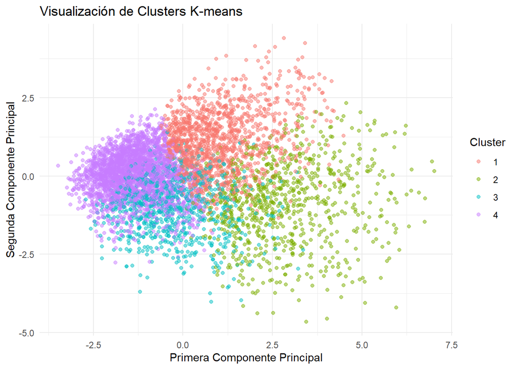

```r
pca_result <- prcomp(movies_scaled)
cluster_plot <- data.frame(
  PC1 = pca_result$x[,1],
  PC2 = pca_result$x[,2],
  Cluster = as.factor(kmeans_result$cluster)
)

ggplot(cluster_plot, aes(x = PC1, y = PC2, color = Cluster)) +
  geom_point(alpha = 0.5) +
  theme_minimal() +
  labs(title = "Visualización de Clusters K-means",
       x = "Primera Componente Principal",
       y = "Segunda Componente Principal")
```

## Análisis de componentes

### 3.1 ¿Qué variables categóricas serán necesarias?

Primero se deben analizar cuáles variables serán importantes para el análisis y cuáles pueden descartarse.

Las variables del dataset son: ID: es una variable cualitativa nominal, pues sirve para identificar cada película

Popularity: es una variable cuantitativa medible continua pues es una cantdad que puede medirse en base a ciertos criterios.

Budget: es una variable cuantitativa contable pues representa una cantidad de dinero.

Revenue: es una variable cuantitativa contable ya que representa una cantidad de dinero.

“Original title: es una variable cualitativa nominal ya que sirve para identificar el nombre de cada película.”

Original language: es una variable cualitativa nominal ya que sirve para indicar en que lenguaje se hizo la película originalmente.

Title: es una variable cualitativa nominal y sirve para indicar cuál es el título en inglés de la película

Home page: es una variable cualitativa nominal y sirve para indicar si la película tiene un sitio web.

Video: es una variable cualitativa nominal, pues sirve para idnciar si la película tiene promocionales o no.

Director: es una variable cualitativa nominal la cua´l indica el nombre del director de la película.

Runtime: es una variable cuantitativa continua medible, pues sirve para indicar el tiempo de duración de la película el cuál puede ser perfectamente medido con aparatos como un temporizador o cronómetro.

Genres: es una variable cualitativa nominal pues sirve para identificar los géneros de la película.

Genres amount: es una variable cuantitativa discreta pues indica la cantidad de géneros a los que pertence cada película.

Production company: es una variale cualitativa nominal la cual indica la compañía que produjo la película.

Production company amount: es una variable cuantitativa discreta que indica la cantidad de compañías involucradas en la producción de la película.

Production company country: es una variable cualitativa nominal pues sirve para indicar que países estuvieron involucrados en la producción de la película.

Production countries amount: es una variable cuantitativa discreta la cuál indica la cantidadde países involucrados en la producción de la película.

Release date: es una variable cuantitativa nominal pues indica la fecha de lanzamiento de la película. A pesar de ser numeral no es cuantitativa pues no puede contarse.

Vote count: es una variable cuantitativa discreta pues indica la cantidad de gente que reseñó la película.”

Actors: es una variable cualitativa nominal la cuál indica el nombre de los actores involucrados en la película.

“Actors popularity: es una variable cuantitatva discreta la cuál sirve panra indicar, en números decimales, que tan poular es un actor.”

Actor Character: es una variable cualitativa nominal pues sirve para indicar el nombre del personaje que interpreta cada actor en la película.

Actors amount: es una variable cuantitativa discreta pues indica la cantidad de actores que están involucrados en la película.

Cast women amount: es una variable cuantitativa discreta la cuál indica la cantidad de actrices que participaron en la película.

Cast men amount: es una variable cuantitativa discreta que indica la canidad de actores que participaron el la película.

La variable ID y las variables que corresponden a los títulos de la películas pueden descartarse, pues su único propósito es identificar cada película. Otra variables descartables son las variables Actor Character y Actors pues simplemente indican los nombres de los actores involucrados en la película y los personajes a los que interpertan.

La variable video puede perecer descartable, sin embargo puede dar información relevante para determinar el comportamiento de una película pues podría ser que el hecho de tener videos ayude al rendimiento en taquilla de una película o no. También podría ser útil para determinar si el presupuesto de una película se ve afectado si tiene videos promocionales.

La variable genres es de utilidad ya que puede ser de ayuda para determinar si hay géneros de películas más famosos que otros o no, en el análisis exploratorio se determióo que hay géneros de películas que han obtenido mejores rendimientos en taquilla y que son más populares que otros por lo que los géneros de una película pueden ser una pieza de información relevante. Sin embargo la columna genres posee un formato complicado el cuál aumentaría la dimensionalidad del dataset, por ende se usuará la variable genres amount y se determinará si la diversidad de géneros afecta el rendimiento de una película o si atrae a más cientes.

Si una película tiene o no un sitio web también puede ser relvante para el análisis pues podría considerarse como parte de la promoción de la película, por lo que esta variable puede ser de importancia para el análisis.

La fecha de lanzamiento también es relevante pues en el análisis exploratorio se demostró que hay épocas del año en donde las películas obtienen mejores ingresos, por ende se requiere extraer el mes de lanzamiento de cada película para el análisis.

La variable director es importante ya que hay directores más famosos que otros sin embargo hay bastantes directores diferentes en el dataset, por lo que asignarle un número a cada uno podría darnos un rango de números bastante elevado. Por esa razón se convertirán ess valores a la cantidad de directores involucrados y se analizara si la cantidad de directores pesa en el desempeño de una película

El país de origen es importante, sin embargo hay películas, por esta razón se usará la variable productionCountriesAmount y se determinará si el hecho de que la película esté distribuida en más, o menos cantidad de películas es importante o no.

El nombre de la distribuidora también es importante, sin embargo hay muchas distribuidoras, por esa razón se usará la variable de production amount para determinar si tener una o más productoras involucradas es importante para la película.

El lenguaje original también puede ser un factor importante, por lo que se convertirán a factores los valores de esta variable

```r
#Transformación de la data

movies_pca <-movies

#Convertimos las columnas relacionadas a los videos procionales


movies_pca$video[is.na(movies_pca$video)] <- FALSE
movies_pca$video<- as.numeric(factor(movies_pca$video)) #2 true, 1 false
#Trasnformamos los valores NA de la variable del website
movies_pca$homePage[!is.na(movies_pca$homePage)] <- TRUE
movies_pca$homePage[is.na(movies_pca$homePage)] <- FALSE
movies_pca$homePage<- as.numeric(factor(movies_pca$homePage))  #2 true, 1 false

movies_pca <- na.omit(movies_pca)

#Transformar el lenguage original
movies_pca$originalLanguage<- as.numeric(factor(movies_pca$originalLanguage))


#Obtener los meses de lanzamiento de cada película

movies_pca$releaseDate <- as.numeric(format(as.Date(movies_pca$releaseDate, format="%Y-%m-%d"), "%m"))

#Cambiar los valores de la columna del director.

movies_pca$director <- sapply(gregexpr("\\|", movies_pca$director), function(x) sum(x >= 0)) + 1

movies_pca$actorsPopularity <- sapply(strsplit(movies_pca$actorsPopularity, "\\|"),
                                  function(x) mean(as.numeric(x), na.rm = TRUE))

movies_pca$castWomenAmount <- as.integer(movies_pca$castWomenAmount)
movies_pca$castMenAmount <- as.integer(movies_pca$castMenAmount)
```

### 3.2 ¿Es conveniente hacer PCA?

```r
library(psych)
```

```r
library(FactoMineR)
library(factoextra)
library(corrplot)
movies_final <- movies_pca[, c("budget", "homePage", "revenue", "runtime", "video", "director", "actorsPopularity", "originalLanguage", "popularity", "releaseDate", "voteAvg", "voteCount", "genresAmount", "productionCoAmount", "productionCountriesAmount", "actorsAmount", "castWomenAmount", "castMenAmount" )]


rcor <- cor(movies_final, use = "pairwise.complete.obs")
det(rcor)
```

```
## [1] 0.05361342
```

El valor del determinate de la matriz es de 0.0536134, es más cercano a 0 que a 1, por lo que se puede decir que las variables si están relacionadas

#### KMO

```r
KMO(as.matrix(movies_final))
```

```
## Kaiser-Meyer-Olkin factor adequacy
## Call: KMO(r = as.matrix(movies_final))
## Overall MSA =  0.64
## MSA for each item =
##                    budget                  homePage                   revenue
##                      0.75                      0.85                      0.68
##                   runtime                     video                  director
##                      0.69                      0.44                      0.63
##          actorsPopularity          originalLanguage                popularity
##                      0.63                      0.49                      0.79
##               releaseDate                   voteAvg                 voteCount
##                      0.52                      0.53                      0.74
##              genresAmount        productionCoAmount productionCountriesAmount
##                      0.62                      0.55                      0.46
##              actorsAmount           castWomenAmount             castMenAmount
##                      0.34                      0.37                      0.45
```

Se obtuvo que el MSA es de 0.64, por lo que la adecuación muestral para el análisis factorial es aceptable.

#### Prueba esfericidad de Bartlett.

Por último se hará este prueba para verificar completamente si se puede hacer un análisis de componentes sobre el dataset

```r
cortest.bartlett(rcor)
```

```
## $chisq
## [1] 269.6756
##
## $p.value
## [1] 1.799032e-08
##
## $df
## [1] 153
```

El p value es de 1.799032e-08, por lo que este test también sugiere que es adecuado hacer un análisis de componentes.

## Interpretacion de los resultados

```r
movies_clean$cluster <- as.factor(kmeans_result$cluster)

# Estadísticas descriptivas por cluster
cluster_stats <- movies_clean %>%
  group_by(cluster) %>%
  summarise(
    n = n(),
    # Medidas de tendencia central
    avg_budget = mean(budget, na.rm = TRUE),
    avg_revenue = mean(revenue, na.rm = TRUE),
    avg_runtime = mean(runtime, na.rm = TRUE),
    avg_popularity = mean(popularity, na.rm = TRUE),
    avg_vote = mean(voteAvg, na.rm = TRUE),
    avg_vote_count = mean(voteCount, na.rm = TRUE),
    avg_actors = mean(actorsAmount, na.rm = TRUE),
    avg_women = mean(castWomenAmount, na.rm = TRUE),
    avg_men = mean(castMenAmount, na.rm = TRUE),
    # Medidas de dispersión
    sd_budget = sd(budget, na.rm = TRUE),
    sd_revenue = sd(revenue, na.rm = TRUE),
    # Métricas derivadas
    roi = (mean(revenue, na.rm = TRUE) - mean(budget, na.rm = TRUE)) / mean(budget, na.rm = TRUE)
  )

print("Análisis de Clusters:")
```

```
## [1] "Análisis de Clusters:"
```

```r
print(cluster_stats)
```

```
## # A tibble: 4 × 14
##   cluster     n avg_budget avg_revenue avg_runtime avg_popularity avg_vote
##   <fct>   <int>      <dbl>       <dbl>       <dbl>          <dbl>    <dbl>
## 1 1        1315   4717988.    7409286.       106.            19.4     6.56
## 2 2         796  25109075.   54828551.       106.            26.5     6.43
## 3 3         873   4673659.    4914797.       101.            20.5     6.33
## 4 4        2513   1666754.    2610763.        93.9           23.9     6.29
## # ℹ 7 more variables: avg_vote_count <dbl>, avg_actors <dbl>, avg_women <dbl>,
## #   avg_men <dbl>, sd_budget <dbl>, sd_revenue <dbl>, roi <dbl>
```

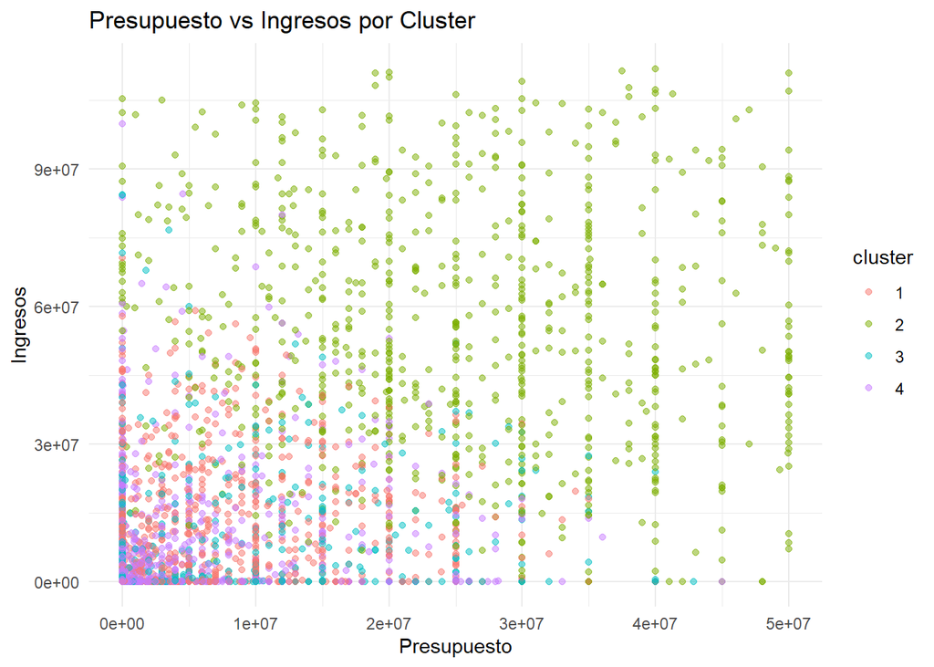

```r
# Presupuesto vs Ingresos
ggplot(movies_clean, aes(x = budget, y = revenue, color = cluster)) +
  geom_point(alpha = 0.5) +
  theme_minimal() +
  labs(title = "Presupuesto vs Ingresos por Cluster",
       x = "Presupuesto",
       y = "Ingresos")
```

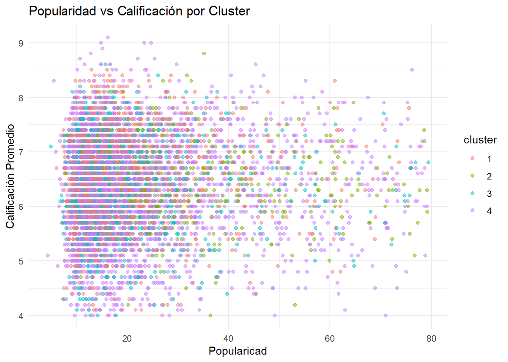

```r
# Popularidad vs Calificación promedio
ggplot(movies_clean, aes(x = popularity, y = voteAvg, color = cluster)) +
  geom_point(alpha = 0.5) +
  theme_minimal() +
  labs(title = "Popularidad vs Calificación por Cluster",
       x = "Popularidad",
       y = "Calificación Promedio")
```

###Interpretación de los Grupos y Hallazgos Distribución de los Clusters (K-means)

La distribución de clusters ordenadas de mayor a menor, me dio lo siguiente:

####Calidad del Agrupamiento